# GED16/AO808: Análise de Regressão

## Transformação Box-Cox

```r
library(MASS)
```

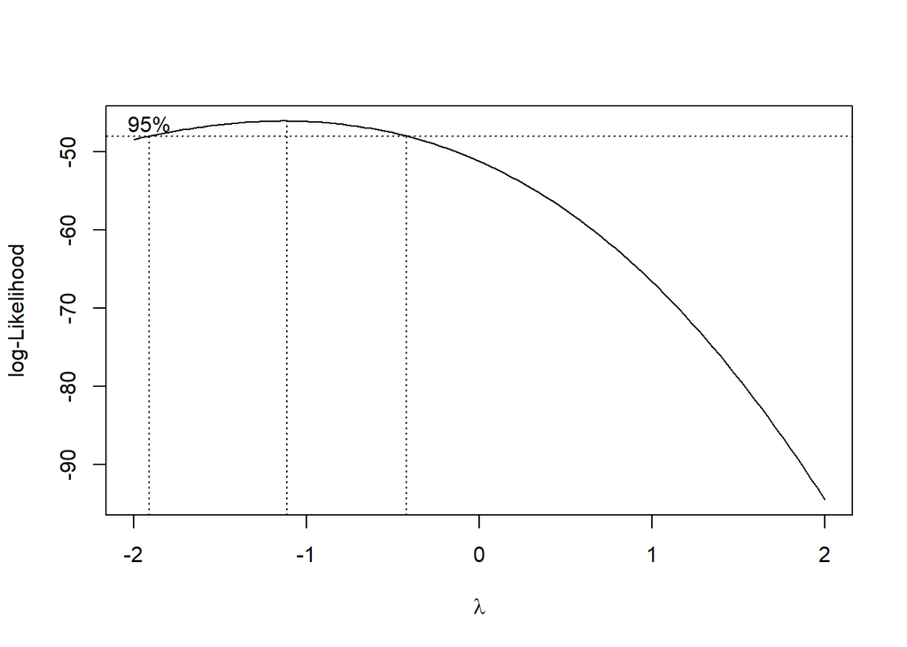

```r
 #InfectRIsk
bcir <- boxcox(lm(LengthStay ~ InfectRisk), lambda = seq(-2, 2, by = 0.1), plotit = TRUE)
```

```r
(lambdair <- bcir$x[which.max(bcir$y)])
```

```
## [1] -1.111111
```

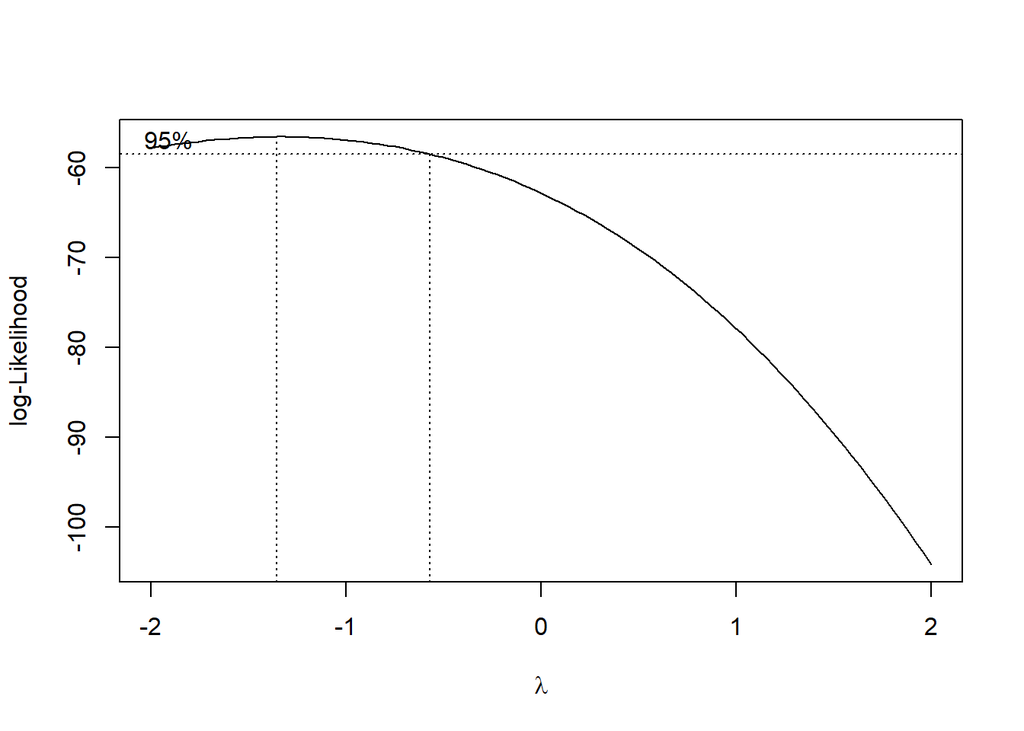

```r
#Facilities
bcfa <- boxcox(lm(LengthStay ~ Facilities), lambda = seq(-2, 2, by = 0.1), plotit = TRUE)
```

```r
(lambdafa <- bcfa$x[which.max(bcfa$y)])
```

```
## [1] -1.353535
```

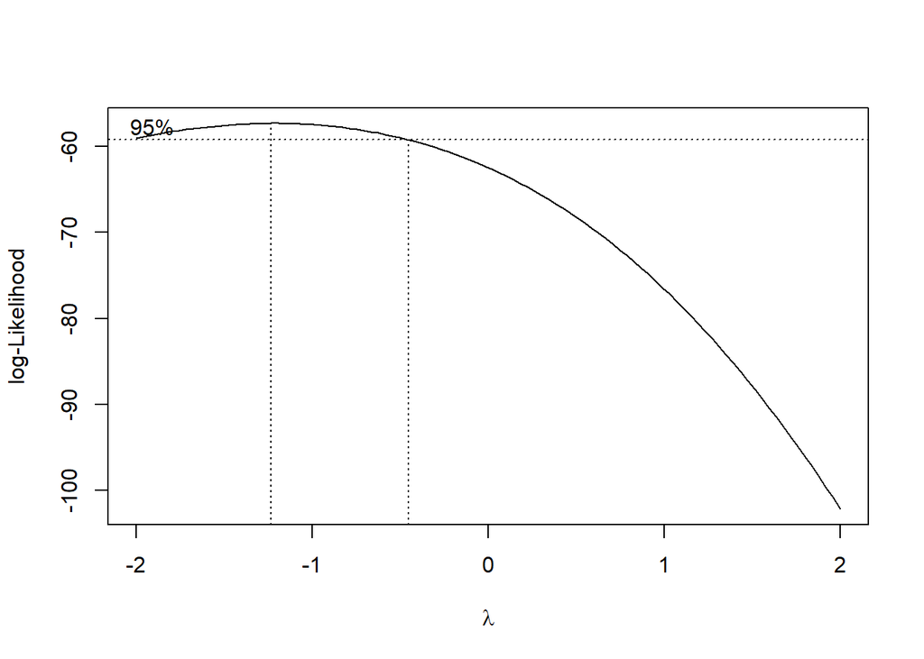

```r
#XrayRatio
bcxr <- boxcox(lm(LengthStay ~ XrayRatio), lambda = seq(-2, 2, by = 0.1), plotit = TRUE)
```

```r
(lambdaxr <- bcxr$x[which.max(bcxr$y)])
```

```
## [1] -1.232323
```

InfectRisk: O valor de $\lambda$ que maximiza a função de verossimilhança (ou melhor, o logaritmo dessa função) é próximo de -1.1, o que indica que a transformação $\frac{1}{Y^{1.1}}$ deve ser aplicada. Sendo assim, replicaremos o procedimento realizado para as variáveis transformadas:

```r
#Transforma da variável de resposta

LengthStay_bcir <- 1/(LengthStay^(1.1))

# Constrói nova base de dados
data_rls_bcir <- data.frame(InfectRisk = InfectRisk, LengthStay_bcir = LengthStay_bcir )

# Ajusta modelo de regressão linear simples aos dados transformados
scenic_rls_bcir <- lm(LengthStay_bcir ~ InfectRisk, data = data_rls_bcir)

# Gera resumo do modelo de regressão ajustado
summary(scenic_rls_bcir)
```

```
##
## Call:
## lm(formula = LengthStay_bcir ~ InfectRisk, data = data_rls_bcir)
##
## Residuals:
##       Min        1Q    Median        3Q       Max
## -0.034087 -0.007782 -0.000250  0.006908  0.038646
##
## Coefficients:
##              Estimate Std. Error t value Pr(>|t|)
## (Intercept)  0.113375   0.004241  26.734  < 2e-16 ***
## InfectRisk  -0.006360   0.000931  -6.831 4.74e-10 ***
## ---
## Signif. codes:  0 '***' 0.001 '**' 0.01 '*' 0.05 '.' 0.1 ' ' 1
##
## Residual standard error: 0.01321 on 111 degrees of freedom
## Multiple R-squared:  0.296,  Adjusted R-squared:  0.2896
## F-statistic: 46.66 on 1 and 111 DF,  p-value: 4.736e-10
```

Modelo ajustado:

$\frac{1}{LengthStay^{1.1}} = -0.00636*InfectRisk + 0.113375$

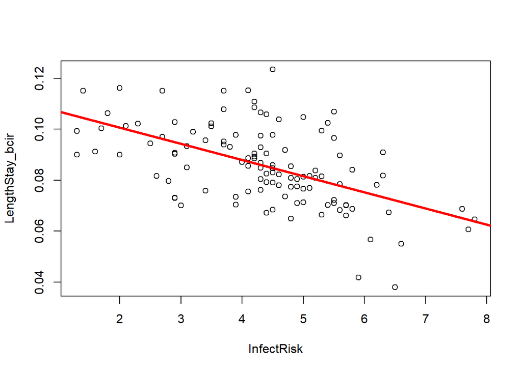

```r
# Adiciona curva de regressão estimada ao gráfico de dispersão
plot(data_rls_bcir)
abline(scenic_rls_bcir$coef, col = 2, lwd = 3)
```

Precisamos realizar o diagnóstico do novo modelo:

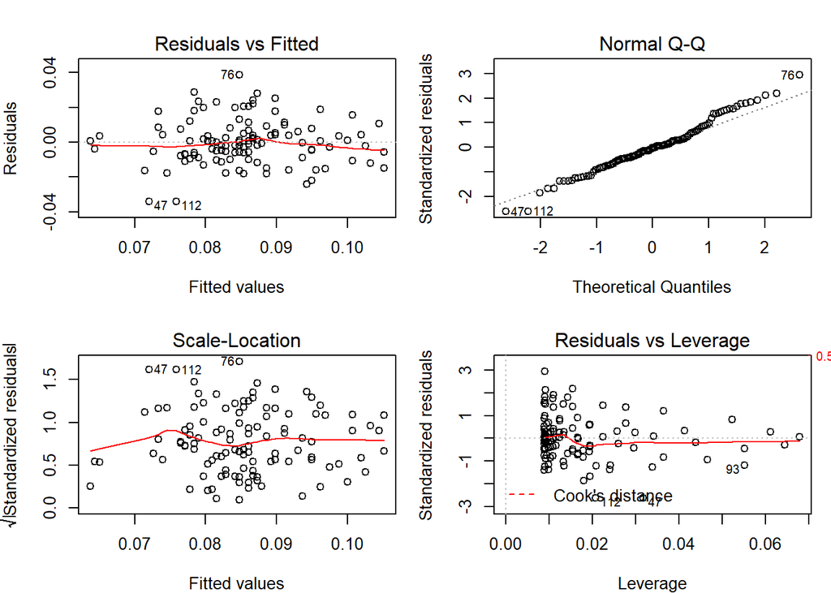

```r
par(mfrow = c(2,2), mar=c(4,4,3,1))
# Produz gráficos dos resíduos
plot(scenic_rls_bcir)
```

Facilities:

O valor de $\lambda$ que maximiza a função de verossimilhança (ou melhor, o logaritmo dessa função) é próximo de -1.3, o que indica que a transformação $\frac{1}{Y^{1.3}}$ deve ser aplicada. Sendo assim, replicaremos o procedimento realizado para as variáveis transformadas:

```r
#Transforma da variável de resposta

LengthStay_bcfa <- 1/(LengthStay^(1.3))

# Constrói nova base de dados
data_rls_bcfa <- data.frame(Facilities = Facilities, LengthStay_bcfa = LengthStay_bcfa)

# Ajusta modelo de regressão linear simples aos dados transformados
scenic_rls_bcfa <- lm(LengthStay_bcfa ~ Facilities, data = data_rls_bcfa)

# Gera resumo do modelo de regressão ajustado
summary(scenic_rls_bcfa)
```

```
##
## Call:
## lm(formula = LengthStay_bcfa ~ Facilities, data = data_rls_bcfa)
##
## Residuals:
##        Min         1Q     Median         3Q        Max
## -0.0315774 -0.0069620 -0.0000135  0.0072264  0.0278579
##
## Coefficients:
##               Estimate Std. Error t value Pr(>|t|)
## (Intercept)  6.799e-02  3.106e-03  21.891  < 2e-16 ***
## Facilities  -3.007e-04  6.791e-05  -4.429 2.23e-05 ***
## ---
## Signif. codes:  0 '***' 0.001 '**' 0.01 '*' 0.05 '.' 0.1 ' ' 1
##
## Residual standard error: 0.01092 on 111 degrees of freedom
## Multiple R-squared:  0.1502, Adjusted R-squared:  0.1425
## F-statistic: 19.61 on 1 and 111 DF,  p-value: 2.231e-05
```

Modelo ajustado:

$\frac{1}{LengthStay^{1.3}} = -0.0003*Facilities + 0.068$

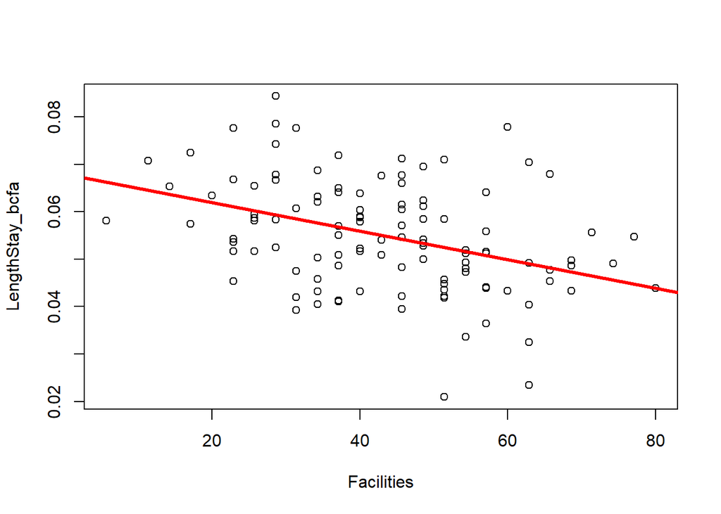

```r
# Adiciona curva de regressão estimada ao gráfico de dispersão
plot(data_rls_bcfa)
abline(scenic_rls_bcfa$coef, col = 2, lwd = 3)
```

Precisamos realizar o diagnóstico do novo modelo:

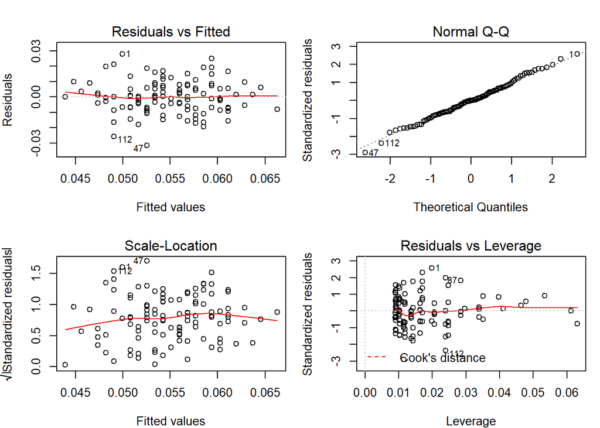

```r
par(mfrow = c(2,2), mar=c(4,4,3,1))
# Produz gráficos dos resíduos
plot(scenic_rls_bcfa)
```

XrayRatio: O valor de $\lambda$ que maximiza a função de verossimilhança (ou melhor, o logaritmo dessa função) é próximo de -1.2, o que indica que a transformação $\frac{1}{Y^{1.2}}$ deve ser aplicada. Sendo assim, replicaremos o procedimento realizado para as variáveis transformadas:

```r
#Transforma da variável de resposta

LengthStay_bcxr <- 1/(LengthStay^(1.2))

# Constrói nova base de dados
data_rls_bcxr <- data.frame(XrayRatio = XrayRatio, LengthStay_bcxr = LengthStay_bcxr)

# Ajusta modelo de regressão linear simples aos dados transformados
scenic_rls_bcxr <- lm(LengthStay_bcxr ~ XrayRatio, data = data_rls_bcxr)

# Gera resumo do modelo de regressão ajustado
summary(scenic_rls_bcxr)
```

```
##
## Call:
## lm(formula = LengthStay_bcxr ~ XrayRatio, data = data_rls_bcxr)
##
## Residuals:
##       Min        1Q    Median        3Q       Max
## -0.034671 -0.008227 -0.000078  0.007840  0.033166
##
## Coefficients:
##               Estimate Std. Error t value Pr(>|t|)
## (Intercept)  9.015e-02  5.202e-03  17.331  < 2e-16 ***
## XrayRatio   -2.635e-04  6.202e-05  -4.249 4.49e-05 ***
## ---
## Signif. codes:  0 '***' 0.001 '**' 0.01 '*' 0.05 '.' 0.1 ' ' 1
##
## Residual standard error: 0.01271 on 111 degrees of freedom
## Multiple R-squared:  0.1399, Adjusted R-squared:  0.1321
## F-statistic: 18.05 on 1 and 111 DF,  p-value: 4.489e-05
```

Modelo ajustado:

$\frac{1}{LengthStay^{1.2}} = -0.00026*XrayRatio + 0.09$

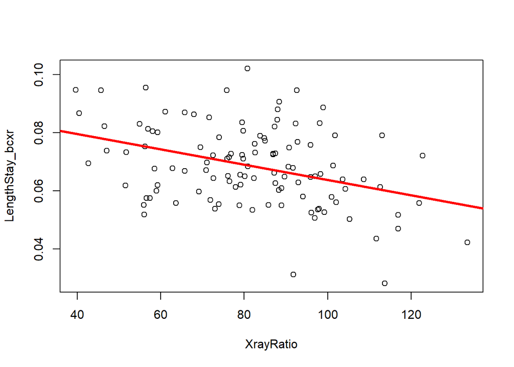

```r
# Adiciona curva de regressão estimada ao gráfico de dispersão
plot(data_rls_bcxr)
abline(scenic_rls_bcxr$coef, col = 2, lwd = 3)
```

Precisamos realizar o diagnóstico do novo modelo:

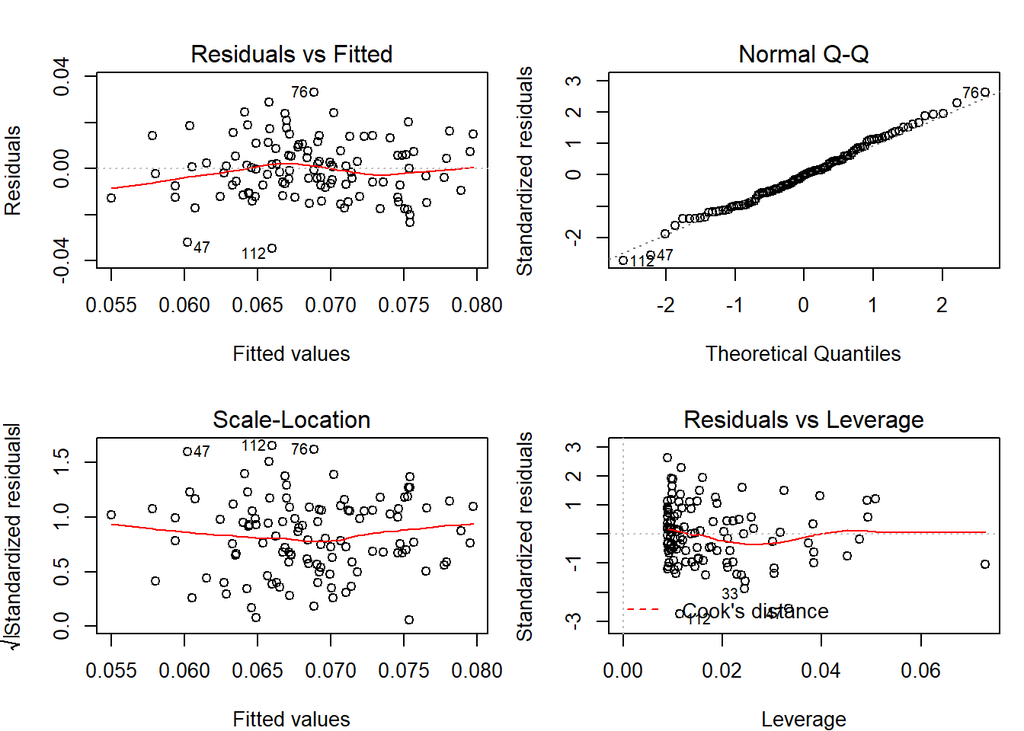

```r
par(mfrow = c(2,2), mar=c(4,4,3,1))
# Produz gráficos dos resíduos
plot(scenic_rls_bcxr)
```

```r
newdata_rls <- data_rls[-c(47,112), ]
newir_rls <- lm(LengthStay ~ InfectRisk, data = newdata_rls)
newlengthstay_orig <- newir_rls$fit
```

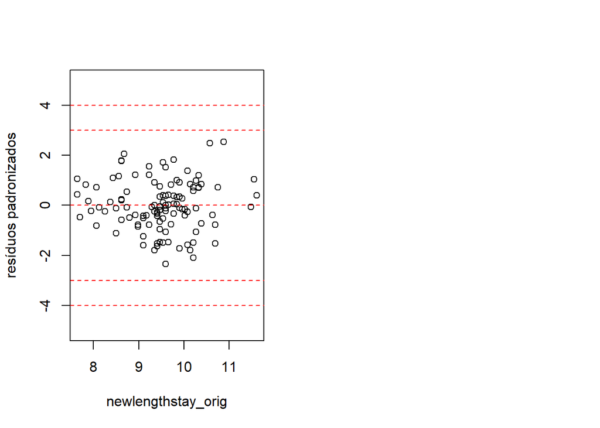

```r
par(mfrow=c(1,2))

# Gráficos para os resíduos padronizados
newresid_rls_pad <- rstandard(newir_rls)

plot(newresid_rls_pad ~ newlengthstay_orig, ylim=c(-5,5),
     ylab="resíduos padronizados")
abline(h = c(-4, -3, 0, 3, 4) , col = "red", lty = "dashed")
```

```r
Xi1 <- data.frame(InfectRisk = 6.5)
predict.lm(newir_rls, newdata = Xi1, interval="confidence", level = 0.95)
```

```
##        fit      lwr      upr
## 1 10.81259 10.36399 11.26118
```

```r
Xi2 <- data.frame(InfectRisk = 5.9)
predict.lm(newir_rls, newdata = Xi2, interval="confidence", level = 0.95)
```

```
##        fit      lwr      upr
## 1 10.44674 10.08424 10.80923
```

Concluimos que, com 95% de confiança, para InfectRisk = 6.5 o valor de LengthStay está entre 10.36399 e 11.26118 dias. Já para InfectRisk = 5.9, com 95% de confiança que LengthStay está entre 10.08424 e 10.80923 dias. Portanto, as observações removidas não estão no intervalo de confiança encontrado, pois eram de LengthStay = 19.56 e 17.94 dias. Logo, foi coerente a remoção de ambas observações.

Contudo, como a amostra é pequena, a presença de dois possíveis outliers pode ser muito impactante. Portanto, faremos a remoção desses pontos antes de fazer medidas corretivas.

1. Assuma que um modelo de regressão linear simples é adequado para modelar a relação da variável de resposta `LengthStay` a cada uma das variáveis explicativas `InfectRisk`, `Facilities` e `XrayRatio`.
- Construa um modelo de regressão para cada um desses pares de variáveis;
- Construa gráficos de dispersão (separados) com as retas de regressão ajustadas para cada caso;
- Calcule o MSE para cada modelo. Que variável explicativa produz menor variabilidade em torno da reta de regressão ajustada?
- Utilizando R<sup>2</sup> como critério, qual das variáveis explicativas contribui para a maior redução na variabilidade da resposta `LengthStay`?
2. Para cada região geográfica, construa um modelo de regressão para a variável de resposta `LengthStay` em função de `InfectRisk`. Assuma que o modelo de 1a. ordem é adquado para modelar essas relações. Obtenha os modelos de regressão ajustados.
- As funções de regressão estimadas são semelhantes para as quatro regiões? Discuta.
- Calcule o MSE para cada região. A variabilidade em torno da reta de regressão ajustada é semelhante para as quatro regiões?
- Construa intervalos de confiança 95% para o coeficiente angular da reta de regressão para cada região. As retas de regressão para diferentes regiões parecem ter mesma inclinação? O que se pode concluir?
- Construa intervalos de confiança para a resposta esperada correspondendo a `InfectRisk = 5`, para cada região. O que se pode concluir?
- Construa intervalos de previsão para um novo hospital em cada região que tenha `InfectRisk = 5`. O que se pode concluir?

### Diagnóstico

1. Para cada um dos três modelos de regressão ajustados no item (1) da seção anterior, realize o diagnóstico através da análise dos resíduos e apresente um resumo de suas conclusões. O modelo de regressão linear simples clássico é adequado a alguma das situações investigadas?
2. Ajuste um modelo de regressão linear simples para a variável `LengthStay` como função de `InfectRisk` após excluir as observações 47 (X = 6.5 e Y = 19.56) e 112 (X = 5.9 e Y = 17.94). Obtenha intervalos de previsão de 95% de confiança para novas observações que apresentam valores da variável explicativa iguais a 6.5 e 5.9. As observações eliminadas encontram-se nos limites dos intervalos de previsão obtidos? Discuta o significado dos resultados obtidos.
3. Para os modelos considerando cada região geográfica separadamente no item (2) da seção anterior, realize o diagnóstico através da análise dos resíduos. Todas as regiões aparentam ter mesma variância dos erros? Que conclusões é possível obter a partir da análise?